# Benthic habitats and VME fauna on the Tasmanian Seamounts

Report of Data School FOCUS learnings

Franziska Althaus

CSIRO Oceans & Atmosphere

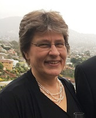

# Introduction

I work in CSIRO Oceans and Atmosphere on deep-sea observational data from the outer continental shelf and the continental slope.

# My Project

My current project is analysing still images of the seafloor on seamounts south of Tasmania, collected using a towed camera system. The images are annotated for (1) percent cover of substrate types, including non-biotic rocks, sediments etc and a matrix forming stony coral, distinguished into live and dead fractions; and (2) for density (number of individuals per m<sup>2</sup>) of taxa considered indicators for vulnerable marine ecosystems (VMEs).

## Preliminary results

In total 6100 images have been selected for annotation which is done in separate software and still ongoing. To date 4987 images have been annotated for percent cover of substrate types in TransectMeasure software from [SEAGIS](https://www.seagis.com.au/), and 3288 have been annotated for VME taxa in the CSIRO insidence of the MBARI developed Video Annotation and Registration System ([VARS](http://vars.it.csiro.au/)).

Combinig the percent cover and density data into a by-image data matrix, which although not an officially tidy format is a useful output for taking the data into [QGIS](https://qgis.org/en/site/) for mapping visualisations.

```r
# creaing a summary of the total density of VME indicator taxa

VMEonly_TotDens <- VMEanno_DensQ %>%
  filter( CONCEPT == "Black & Octocorals" |
                  CONCEPT == "Brisingid"  |
                  #CONCEPT == "D.horridus",
                  CONCEPT == "Enallopsammia"  |
                  #CONCEPT == "Hydrocorals"  |
                  CONCEPT == "Hydrocorals: Branching"  |
                  #CONCEPT == "Irregular urchins"  |
                  CONCEPT == "Madrepora"  |
                  #CONCEPT == "No-VMEfauna",
                  #CONCEPT == "Regular urchins"  |
                  CONCEPT == "S.variabilis"  |
                  CONCEPT == "Sponges"  |
                  CONCEPT == "Stalked crinoids"  |
                  CONCEPT == "Stony corals",
                  #CONCEPT == "True anemones: Fourlobed"  |
                  #CONCEPT == "Unstalked crinoids"
          )%>%
  group_by(image_key, SVY_OPS, MapLoc, depth) %>%
  summarise(VMEtaxaDens=sum(Dens))

#temporary table: add summary of total density of VME taxa to densities of separated counted taxa

 TVME <- VMEannoMatrix %>%
  select(image_key,
         `Black & Octocorals`,
         `Brisingid`,
         `D.horridus`,
         `Enallopsammia`,
         `Hydrocorals`,
         `Hydrocorals: Branching`,
         `Irregular urchins`,
         `Madrepora`,
         `No-VMEfauna`,
         `Regular urchins`,
         `S.variabilis`,
         `Sponges`,
         `Stalked crinoids`,
         `Stony corals`,
         `True anemones: Fourlobed`,
         `Unstalked crinoids`,
         PC_Sub_CoralReef,
         PC_EnallopMatrix,
         PC_SolMatrix) %>%
  left_join(VMEonly_TotDens, by=c("image_key"="image_key")) %>%
  select(-MapLoc, -depth, -SVY_OPS)


# select out the Percent cover values from PC_Matrix and add this to the table above

VME_AnnoAll <- PCcoverbyImage %>%
  select(image_key,
         'SC-ENLP',
         'SU-ENLP',
         'SC-SOL',
         'SU-SOL',
         'SC-MAD',
         'SU-MAD',
         'SU-BCOR',
         'SU-BBAR',
         'SU-BOTH',
         'SU-ROK',
         'SU-BOL',
         'SU-COB',
         'SU-CONBIO',
         'SU-PEBGRAV',
         'SU-SAMU',
         'NS') %>%
  inner_join(TVME, by=c("image_key"="image_key"))
```

```r
#Reading out the first 5 lines of the data
kable(head(VME_AnnoAll, n=5), caption ="Combined data matrix (by image) of percent substrate types and VME taxon densities, including the summaries of densities") %>%
  kable_styling("striped") %>%
  scroll_box(width = "100%")
```

Table 1: Combined data matrix (by image) of percent substrate types and VME taxon densities, including the summaries of densities

| image_key | SC-ENLP | SU-ENLP | SC-SOL | SU-SOL | SC-MAD | SU-MAD | SU-BCOR | SU-BBAR | SU-BOTH | SU-ROK | SU-BOL | SU-COB | SU-CONBIO | SU-PEBGRAV | SU-SAMU | NS | Black & Octocorals | Brisingid | D.horridus | Enallopsammia | Hydrocorals | Hydrocorals: Branching | Irregular urchins | Madrepora | No-VMEfauna | Regular urchins | S.variabilis | Sponges | Stalked crinoids | … |
| --- | --- | --- | --- | --- | --- | --- | --- | --- | --- | --- | --- | --- | --- | --- | --- | --- | --- | --- | --- | --- | --- | --- | --- | --- | --- | --- | --- | --- | --- | --- |
| 025_0017 | 0 | 0 | 0 | 0 | 0 | 0 | 0 | 0 | 0 | 100 | 0 | 0 | NA | 0 | 0 | 0 | 0.0000000 | 0 | 0 | 0 | 0.1145074 | 0 | 0 | 0 | 0 | 0 | 0 | 0.0000000 | 0 | … |
| 025_0046 | 0 | 0 | 0 | 0 | 0 | 0 | 0 | 0 | 0 | 100 | 0 | 0 | NA | 0 | 0 | 0 | 0.0000000 | 0 | 0 | 0 | 0.4621374 | 0 | 0 | 0 | 0 | 0 | 0 | 0.0000000 | 0 | … |
| 025_0066 | 0 | 0 | 0 | 0 | 0 | 0 | 0 | 0 | 0 | 100 | 0 | 0 | NA | 0 | 0 | 0 | 0.0000000 | 0 | 0 | 0 | 0.1650256 | 0 | 0 | 0 | 0 | 0 | 0 | 0.1650256 | 0 | … |
| 025_0076 | 0 | 0 | 0 | 0 | 0 | 0 | 0 | 0 | 0 | 100 | 0 | 0 | NA | 0 | 0 | 0 | 0.0832810 | 0 | 0 | 0 | 0.0832810 | 0 | 0 | 0 | 0 | 0 | 0 | 0.0000000 | 0 | … |
| 025_0086 | 0 | 0 | 0 | 0 | 0 | 0 | 0 | 0 | 0 | 100 | 0 | 0 | NA | 0 | 0 | 0 | 0.1350974 | 0 | 0 | 0 | 0.1350974 | 0 | 0 | 0 | 0 | 0 | 0 | 0.4052922 | 0 | … |

QGIS is my preferred tool for creating maps because it allows for interactive zooming.

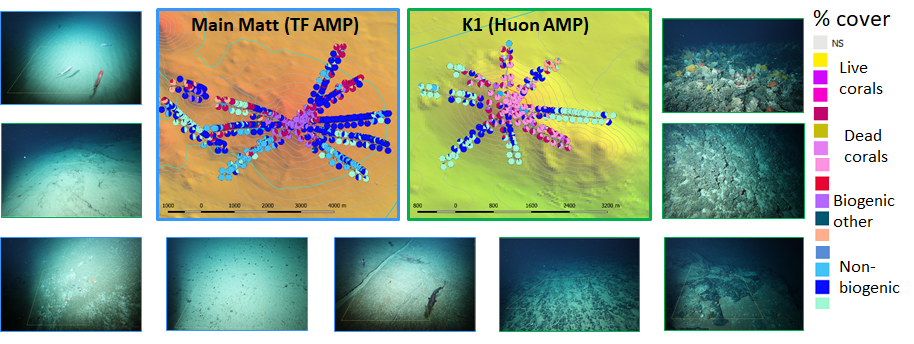

**Plate 1** Example of the percent cover data from transects on two separate seamounts and a selection of example images illustrating the substrate types

The distribution of the live and dead coral matrix formed by Solenosmilia variabilis_ (coded as SC_SOL and SU_SOL) is of particular interest, because this coral is a structural engineer forming biogenic habitats that are particularly vulnerable to impacts by demersal trawling.

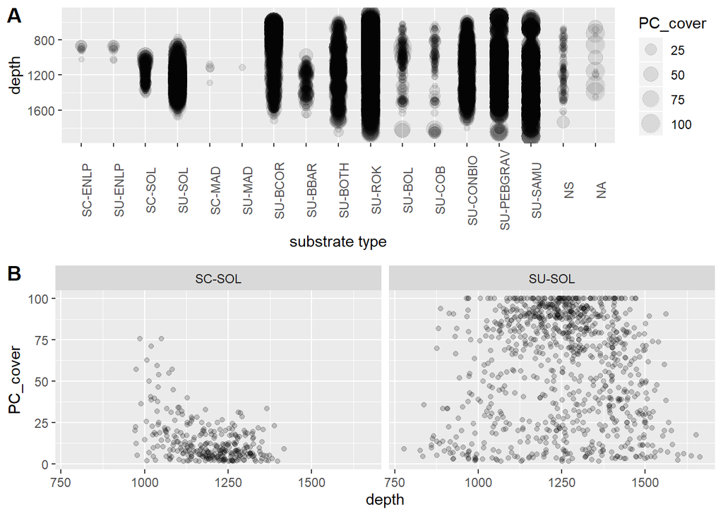

Figure 1: Depth distribution of (A) all substrate types and (B) individual depth distribution of the percent cover of live (SC_SOL) and dead (SU_SOL) coral matrix

```r
#distribution of the substrate types
# create a vector with the sequence of the substrate types for ordering them in a meaningful way
SubstSeq <- c('SC-ENLP',
              'SU-ENLP',
              'SC-SOL',
              'SU-SOL',
              'SC-MAD',
              'SU-MAD',
              'SU-BCOR',
              'SU-BBAR',
              'SU-BOTH',
              'SU-ROK',
              'SU-BOL',
              'SU-COB',
              'SU-CONBIO',
              'SU-PEBGRAV',
              'SU-SAMU',
              'NS')
Plot1 <- ggplot(PC_cover,
       mapping= aes(x=factor(L2_Code, level =SubstSeq),              #call the pre existing vector
                    y=depth,
                    size=PC_cover)
  )+
  geom_point(alpha=0.1)+
  scale_y_reverse() +                            # reverse y-axis because it represents ocean depth
  theme(axis.text.x = element_text(angle = 90))+   # rotate the label on x-axis
  labs(x="substrate type", y="depth")


Plot2 <- PC_cover %>%
  filter(L2_Code == "SC-SOL" |
         L2_Code == "SU-SOL"  ) %>%
  ggplot(aes(x = depth,
             y = PC_cover))+
  geom_point(alpha=0.2)+
  facet_wrap(~L2_Code)

plot_grid(Plot1, Plot2, ncol=1, labels = c('A', 'B'))
```

The density data distribution of VME taxa shows the typical high frequency of low densities and a rapid decrease and long tail of higher densities of animals in the quadrats (Figure 2).

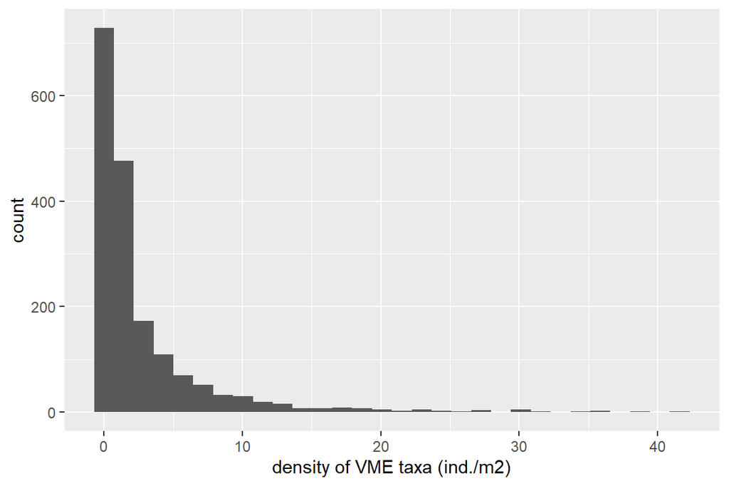

Figure 2: Frequency distribution of total density of VME taxa only

```r
# looking at the distribution of density and number of taxa over the whole data set note non-VME taxa are commented out

VMEonly_TotDens %>%
  ggplot(aes(x = VMEtaxaDens))+
  geom_histogram()+
  labs(x="density of VME taxa (ind./m2)", y="count")
```

The importance of coral matrix as a substrate for various VME taxa is of particular importance, because the matrix is vulnerable to damage and removal by fishing using demersal trawls. Figure 3 shows the relationship between the density of the measured VME taxa and the percent cover of coral matrix substrate.

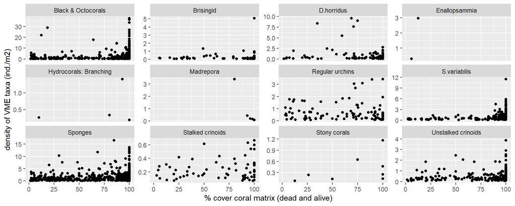

Figure 3: Relationship between the density of idividual VME taxa and the percent cover of matrix forming coral

```r
VMEanno_DensQ %>%
  left_join(PCcoverbyImage, by=c("image_key"="image_key")) %>%
  filter((`SC-SOL`+`SU-SOL`) != 0 &
        CONCEPT != "Hydrocorals" &
        CONCEPT != "True anemones: Fourlobed" &
        CONCEPT != "No-VMEfauna" ) %>%
    ggplot(mapping = aes(x= (`SC-SOL`+`SU-SOL`),
                     y= Dens
                     ))+
   geom_point()+
  labs(x="% cover coral matrix (dead and alive)", y="density of VME taxa (ind./m2)")+
  facet_wrap(~CONCEPT, scales = "free_y")
```

# My Digital Toolbox

My digital toolbox includes:

- SQL: DB-visualiser and ORACLE
- R: tidyverse, dplyr, ggplot, knitr
- Markdown
- QGIS

Through data school I have developed scripts using **R tidyverse** to automate reading, tidying up and quality checking the data extracts from **SQL** queries in the ORACLE database and from direct software outputs.

**MarkDown** with **knitr** is a useful tool for describing the data QC process and presenting data summaries, initial plots (**ggplot**) and analyses to collaborators.

Having automated processing into consistent data outputs facilitates data visualisations in **R** and **QGIS**, and summaries while annotations are still in progress.

# My time went

Much of my time was spent creating scripts for tidying up the data outputs from TransectMesure and VARS into a format that is amenable for analysis and plotting in R and input to QGIS.

# Next steps

In the near future I want to hone my skills in using R for data wrangling and tidying futher for use with my image data projects, and introduce some of these tools into the workflow for my team. I want to apply my new skills to understand and use R projects, BitBucket repositories and Markdown documents my colleagues have ceated under another project I am involved in. This will hopefully lead to my taking over some of the tasks previously done by my colleagues. Finally, I can see the potential in using R and Markdown for new work we have identified in my team: creating a series of descriptions of putative octocoral species, with linkages to photographs and CAAB records, all following the same outline and template. I am keen to explore creating these using a tempate in R, using Markdown.

Data School also introduced me to the usefulness of the CSIRO Research Data Planner - a tool that I intend to employ in current and furture projects.

# My Data School Experience

I liked the format of Data School, it allowed me to get past my initial hesitations about using R and the code based environment. As mentioned throughout this document, I can see many applications of my new found knowledge in my daily work.